# FIESTA - Database Tools

## FIESTA Overview

The R package, FIESTA (Forest Inventory ESTimation and Analysis) is a research estimation tool for analysts that work with sample-based inventory data like that from the U.S. Department of Agriculture, Forest Service, Forest Inventory and Analysis (FIA) Program to accommodate: unique population boundaries, different evaluation time periods, customized stratification schemes, non-standard variance equations, integration of multi-scale remotely-sensed data and other auxiliary information, and interaction with other modeling and estimation tools from CRAN R’s library of packages. FIESTA contains a collection of functions that can access FIA databases, summarize and compile plot and spatial data, and generate estimates with associated sampling errors.

Functions are organized by type or objective and are named with a corresponding prefix:

**Core Functions**

- Database tools (DB) - functions for querying and extracting data from FIA’s national database.
- Data tools (dat) - functions for summarizing and exploring FIA data.
- Spatial tools (sp) - functions for manipulating and summarizing spatial data.

**Estimation Modules**

- Green-Book (GB) - functions for FIA’s standard ‘Green-Book’ estimators.
- Photo-Based (PB) - functions for supplementary photo-based estimators.
- Small Area (SA) - functions for integration with available small area estimators (SAE).
- Model-Assisted (MA) - functions for integration with available Model-Assisted estimators.

**Analysis Tools**

- Analysis tools (an) - wrapper functions for stream-lining estimation processes.

### Overview of FIESTA Database (DB) tools

FIESTA’s DB tools extract data from FIA’s online publicly-available, comma-delimited files (*.csv or *.zip). FIA’s CSV files are available by state from the FIA DataMart at the following link: https://apps.fs.usda.gov/fia/datamart/datamart.html. Because of FIA’s confidentiality agreement to protect the privacy of landowners, as well as protecting the scientific integrity of FIA’s sample design, the exact coordinates of the sample plot locations are not included in the public data. If the exact coordinates are necessary for your analysis, contact FIA’s Spatial Data Services (https://www.fia.fs.fed.us/tools-data/spatial/index.php).

An FIA Evaluation is a group of plots within the FIA database that is used for population estimates. An FIA Evaluation represents different inventory spans of data with different stratification and area adjustments for nonreponse. Each Evaluation is determined by the type of estimation (evalType) including: area and tree estimates, growth and mortality estimates, and area change estimates (evalType). These plots are identified by an evalid, which is a unique identifier in the format of a 2-digit State code, a 2-digit year code, and a 2-digit evaluation type code. For example, EVALID ‘491601’ represents the Utah 2016 evaluation for current area estimates.

| FUNCTION | DESCRIPTION |
| --- | --- |
| DBgetCSV() | Downloads comma-delimited file (.csv) or downloads and extracts a compressed csv file (.zip) from FIA’s online DataMart. |
| DBqryCSV() | Extracts and queries data from FIA’s online DataMart, either CSV or ZIP files. |
| DBgetEvalid() | Gets evalid for identifying an estimation group of plots for state or checks evalid. |
| DBgetXY() | Extracts XY data from FIA database. |
| DBgetPlots() | Extracts inventory plot data from FIA database. |
| DBgetStrata() | Extracts strata information and total acres by estimation unit from FIA database, including plot-level assignment and a data frame with strata weights by estimation unit. |

### Set up

First, you’ll need to load the `FIESTA` library:

```r
library(FIESTA)
```

```r
outfolder <- tempdir()
```

## DB Examples

The following examples extract data from FIA’s online DataMart (https://apps.fs.usda.gov/fia/datamart/datamart.html).

### `DBgetCSV()`

The `DBgetCSV` function extracts data from FIA’s publicly-available, online DataMart CSV/ZIP files. The zip files are extracted on-the-fly from the online website. Web server connections will affect download speeds.

#### Example 1: Extract PLOT data for Wyoming and Utah

**View Example**

```r
WYUTplot <- DBgetCSV(DBtable = "PLOT",
                     states = c("Wyoming", "Utah"))
table(WYUTplot$STATECD)
```

**output**

```
##
##    49    56
## 26977 27340
```

#### DBgetCSV()

```r
## Get plot table for Wyoming
WYplots <- DBgetCSV("PLOT", "Wyoming")
dim(WYplots)
```

**output**

```
## [1] 27340    72
```

```r
## Get plot table for Wyoming and Utah
WYUTplots <- DBgetCSV(DBtable = "PLOT",
                      states = c("Wyoming", "Utah"))
table(WYUTplots$STATECD)
```

**output**

```
##
##    49    56
## 26977 27340
```

```r
## Get survey table for Wyoming
WYsurvey <- DBgetCSV("SURVEY", "Wyoming")
WYsurvey
```

**output**

```
##                CN INVYR P3_OZONE_IND STATECD STATEAB STATENM RSCD ANN_INVENTORY
## 1   3001122010690  1984            N      56      WY Wyoming   22             N
## 2   2701863010690  2000            N      56      WY Wyoming   22             N
## 3  40383603010690  2011            N      56      WY Wyoming   22             Y
## 4  40383604010690  2012            N      56      WY Wyoming   22             Y
## 5  40383605010690  2013            N      56      WY Wyoming   22             Y
## 6  40409732010690  2014            N      56      WY Wyoming   22             Y
## 7  40409733010690  2015            N      56      WY Wyoming   22             Y
## 8  40409734010690  2016            N      56      WY Wyoming   22             Y
## 9  40409735010690  2017            N      56      WY Wyoming   22             Y
## 10 40409736010690  2018            N      56      WY Wyoming   22             Y
## 11 40409737010690  2019            N      56      WY Wyoming   22             Y
## 12 40409738010690  2020            N      56      WY Wyoming   22             Y
##                                             NOTES     CREATED_BY
## 1  Periodic inventory FOR CYCLE=1 AND SUBCYCLE=0. FIADB17_PUBLIC
```

[output cut: 37 more lines]

### `DBqryCSV()`

The `DBqryCSV` function queries table from FIA’ online publicly-available DataMart. The tables in the query must be specified in the sqltables parameter.

#### Example: Multiple Uses

**View Example**

#### DBqryCSV()

```r
# Get number of plots by inventory year for the state of Wyoming
sql1 <- "select INVYR, count(*) AS NBRPLOTS
         from PLOT
         where statecd=56 group by INVYR"
DBqryCSV(sql = sql1,
         states = "Wyoming",
         sqltables = "PLOT")
```

**output**

```
##    INVYR NBRPLOTS
## 1   1984     7724
## 2   2000    10110
## 3   2011     1060
## 4   2012     1077
## 5   2013     1013
## 6   2014     1073
## 7   2015     1061
## 8   2016     1067
## 9   2017     1068
## 10  2018     1019
## 11  2019     1058
## 12  2020       10
```

```r
# Get number of plots by inventory year for Utah and Wyoming
sql3 <- "select STATECD, INVYR, count(*) NBRPLOTS
         from PLOT
         where statecd in(50,33)
         group by STATECD, INVYR"
DBqryCSV(sql = sql3,
         states = c("Vermont", "New Hampshire"),
         sqltables = "PLOT")
```

**output**

```
##    STATECD INVYR NBRPLOTS
## 1       33  1983      697
## 2       33  1997      930
## 3       33  2002      149
## 4       33  2003      141
## 5       33  2004      144
## 6       33  2005      144
## 7       33  2006      198
## 8       33  2007      218
## 9       33  2008      199
## 10      33  2009      195
## 11      33  2010      201
## 12      33  2011      242
## 13      33  2012      255
## 14      33  2013      252
```

[output cut: 28 more lines]

```r
# Get number of plots by inventory year for Iowa (stcd=19) that have silver maple (SPCD=317)
sql4 <- "select p.STATECD, p.INVYR, count(*) NBRPLOTS
         from PLOT p
         join TREE t ON p.CN = t.PLT_CN
         where p.statecd = 19 and t.SPCD = 317
         group by p.STATECD, p.INVYR"
DBqryCSV(sql = sql4,
         states = "IOWA",
         sqltables = c("PLOT", "TREE"))
```

**output**

```
##    STATECD INVYR NBRPLOTS
## 1       19  1990     1698
## 2       19  1999      114
## 3       19  2000       48
## 4       19  2001      148
## 5       19  2002      236
## 6       19  2003      114
## 7       19  2004      103
## 8       19  2005       61
## 9       19  2006      147
## 10      19  2007      215
## 11      19  2008       85
## 12      19  2009       97
## 13      19  2010       61
## 14      19  2011      154
## 15      19  2012      195
## 16      19  2013       82
## 17      19  2014       73
## 18      19  2015       58
## 19      19  2016       18
## 20      19  2017      138
## 21      19  2018      111
## 22      19  2019       86
## 23      19  2020       49
## 24      19  2021       65
```

### `DBgetEvalid()`

The `DBgetEvalid` function gets information for FIA Evaluations.

#### Example 1: Get most current evalid and inventory years for Wyoming

**View Example**

```r
WYeval <- DBgetEvalid(states = "Wyoming",
                      evalCur = TRUE)
```

**output**

```
## Inventory years by state...
```

```r
names(WYeval)
```

**output**

```
##  [1] "states"        "rslst"         "evalidlist"    "invtype"
##  [5] "invyrtab"      "evalTypelist"  "evalEndyrlist" "invyrs"
##  [9] "SURVEY"        "PLOT"
```

```r
WYeval$evalidlist
```

**output**

```
## $Wyoming
## [1] 561901
```

```r
WYeval$invyrs
```

**output**

```
## $Wyoming
## [1] 2011 2012 2013 2014 2015 2016 2017 2018 2019
```

```r
WYeval$invyrtab
```

**output**

```
##     STATECD STATENM STATEAB ANN_INVENTORY INVYR
##  1:      56 Wyoming      WY             Y  2011
##  2:      56 Wyoming      WY             Y  2012
##  3:      56 Wyoming      WY             Y  2013
##  4:      56 Wyoming      WY             Y  2014
##  5:      56 Wyoming      WY             Y  2015
##  6:      56 Wyoming      WY             Y  2016
##  7:      56 Wyoming      WY             Y  2017
##  8:      56 Wyoming      WY             Y  2018
##  9:      56 Wyoming      WY             Y  2019
## 10:      56 Wyoming      WY             Y  2020
```

```r
WYeval$invtype
```

**output**

```
## [1] "ANNUAL"
```

#### Example 2: Get most current evaluations for New York and Texas for VOL and GRM evalTypes

**View Example**

```r
NYTXeval <- DBgetEvalid(states = c("New York", "Texas"),
                        evalType = c("VOL", "GRM"))
```

**output**

```
## Inventory years by state...
```

```r
names(NYTXeval)
```

**output**

```
##  [1] "states"        "rslst"         "evalidlist"    "invtype"
##  [5] "invyrtab"      "evalTypelist"  "evalEndyrlist" "invyrs"
##  [9] "SURVEY"        "PLOT"
```

```r
NYTXeval$evalidlist
```

**output**

```
## $`New York`
## [1] 361901 361903
##
## $Texas
## [1] 481901 481903
```

```r
NYTXeval$evalTypelist
```

**output**

```
## $`New York`
## [1] "EXPVOL"  "EXPGROW"
##
## $Texas
## [1] "EXPVOL"  "EXPGROW"
```

### `DBgetXY()`

The `DBgetXY` function queries XY data from FIA’ online publicly-available DataMart or SQLite database.

#### Example1: Get xy data for the state of Wyoming

**View Example**

#### DBgetXY()

```r
xydat1 <- DBgetXY(states = "Wyoming",
                  eval = "FIA",
                  eval_opts = eval_options(Cur = TRUE)
                  )
```

**output**

```
## Inventory years by state...
```

```r
names(xydat1)
```

**output**

```
## [1] "xyCur_PUBLIC"           "xyqry"                  "xy_opts"
## [4] "pjoinid"                "invyrlst"               "evalInfo"
## [7] "pop_plot_stratum_assgn"
```

```r
head(xydat1$xyCur_PUBLIC)
```

**output**

```
##            PLT_CN LON_PUBLIC LAT_PUBLIC STATECD UNITCD COUNTYCD  PLOT
## 1: 40416936010690  -105.9113   44.10051      56      3        5 80574
## 2: 40416941010690  -105.1505   44.09041      56      3        5 82144
## 3: 40416937010690  -105.8459   44.09896      56      3        5 84749
## 4: 40416938010690  -105.2744   44.10641      56      3        5 88881
## 5: 40416940010690  -105.7737   44.08924      56      3        5 85439
## 6: 40416942010690  -105.7873   44.01129      56      3        5 85850
##           PLOT_ID COUNTYFIPS
## 1: ID560300580574      56005
## 2: ID560300582144      56005
## 3: ID560300584749      56005
## 4: ID560300588881      56005
## 5: ID560300585439      56005
## 6: ID560300585850      56005
```

#### Example 2: Add variable in plot table, PLOT_STATUS_CD, and output spatial

**View Example**

```r
xydat2 <- DBgetXY(states = "Wyoming",
                  eval = "FIA",
                  eval_opts = eval_options(Cur = TRUE),
                  pvars2keep = c("PLOT_STATUS_CD"),
                  issp = TRUE
                  )
```

**output**

```
## Inventory years by state...
```

```r
spxy2 <- xydat2$spxy

## Display points with by PLOT_STATUS_CD (1-light blue; 2-brown; 3-blue)
spxy2$color <- with(spxy2,
          ifelse(PLOT_STATUS_CD == 2, "brown",
                ifelse(PLOT_STATUS_CD == 3, "blue", "light blue")))
plot(sf::st_geometry(spxy2['PLOT_STATUS_CD']), pch = 16, cex = .5,
                     col = spxy2$color)
```

**plot**

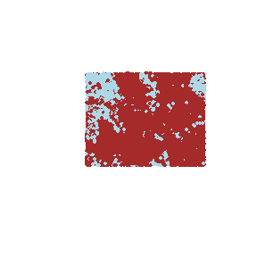

**View Example**

```r
xydat3 <- DBgetXY(states = "Vermont",
                  eval = "custom",
                  eval_opts = eval_options(invyrs = 2017:2019),
                  issp = TRUE
                  )
```

**output**

```
## Inventory years by state...
```

```r
spxy3 <- xydat3$spxy

## Display points
plot(sf::st_geometry(spxy3), pch = 16, cex = .5, col="grey")

## Now only include P2 plots only (intensity1 = TRUE)
xydat3b <- DBgetXY(states = "Vermont",
                  eval = "custom",
                  eval_opts = eval_options(invyrs = 2017:2019),
                  intensity1 = TRUE,
                  issp = TRUE,
                  )
```

**output**

```
## Inventory years by state...
```

```r
spxy3b <- xydat3b$spxy

## Display points
plot(sf::st_geometry(spxy3b), pch = 16, cex = .5, add = TRUE)
```

**plot**

[figure not shown]

### `DBgetPlots()`

The `DBgetPlots` function extracts data from FIA’s online DataMart or SQLite database.

**View Example**

#### DBgetPlots()

```r
dat1 <- DBgetPlots(states = "Rhode Island",
                  eval = "FIA",
                  eval_opts = eval_options(Cur = TRUE,
                                           Type = "ALL"),
                  issp = TRUE
                  )
```

**output**

```
## Inventory years by state...
```

```r
names(dat1)
```

**output**

```
##  [1] "states"                 "tabs"                   "tabIDs"
##  [4] "dbqueries"              "puniqueid"              "xy_PUBLIC"
##  [7] "pop_plot_stratum_assgn" "evalid"                 "pltcnt"
## [10] "invyrs"                 "evalInfo"               "args"
```

```r
plt1 <- dat1$tabs$plt
spxy1 <- dat1$xy_PUBLIC
table(plt1$INVYR)
```

**output**

```
##
## 2015 2016 2017 2018 2019 2020 2021
##   36   38   40   38   36   37   41
```

```r
# Display spatial output
plot(sf::st_geometry(spxy1), pch = 16, cex = .5)


# Add a filter to include only plots with Northern red oak forest type (FORTYPCD == 505)
# Note: *allFilter* filters for plots and/or conditions for all states specified.
dat1b <- DBgetPlots(states = "Rhode Island",
                   eval = "FIA",
                   eval_opts = eval_options(Cur = TRUE,
                                            Type = "ALL"),
                   issp = TRUE,
                   allFilter = "FORTYPCD == 505")
```

**output**

```
## Inventory years by state...
```

```r
names(dat1b)
```

**output**

```
##  [1] "states"                 "tabs"                   "tabIDs"
##  [4] "dbqueries"              "puniqueid"              "xy_PUBLIC"
##  [7] "pop_plot_stratum_assgn" "evalid"                 "pltcnt"
## [10] "invyrs"                 "evalInfo"               "args"
```

```r
spxy1b <- dat1b$xy_PUBLIC
dim(spxy1b)
```

**output**

```
## [1] 12 11
```

```r
# Display spatial output
plot(sf::st_geometry(spxy1b), pch = 16, cex = .5, add = TRUE, col="green")
```

**plot**

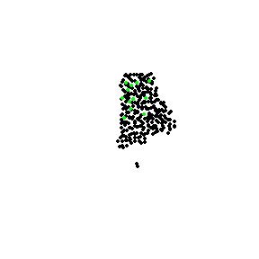

#### Example 3: Get data for Delaware, most current FIA Evaluation, include plotgeom data and subplot tables

**View Example**

```r
dat2 <- DBgetPlots(states = "Delaware",
                   eval = "FIA",
                   eval_opts = eval_options(Cur = TRUE,
                                            Type = "ALL"),
                   issubp = TRUE,
                   plotgeom = TRUE)
```

**output**

```
## Inventory years by state...
```

```r
names(dat2)
```

**output**

```
##  [1] "states"                 "tabs"                   "tabIDs"
##  [4] "dbqueries"              "puniqueid"              "xy_PUBLIC"
##  [7] "pop_plot_stratum_assgn" "evalid"                 "pltcnt"
## [10] "invyrs"                 "evalInfo"               "args"
```

```r
tabs2 <- dat2$tabs
plt2 <- tabs2$plt

## subplot and subp_cond tables are added to tabs list
names(tabs2)
```

**output**

```
## [1] "subplot"   "subp_cond" "plt"       "cond"
```

```r
## PLOTGEOM data are appended to plt table (e.g., ALP_ADFORCD, FVS_VARIANT)
head(plt2)
```

**output**

```
##                CN     PREV_PLT_CN INVYR STATECD CYCLE SUBCYCLE UNITCD COUNTYCD
## 1 168258965020004 145006221010661  2015      10     7        2      1        3
## 2 168258968020004 145006215010661  2015      10     7        2      1        1
## 3 168258973020004 145006227010661  2015      10     7        2      1        3
## 4 168258975020004 145006231010661  2015      10     7        2      1        3
## 5 168258978020004 145006237010661  2015      10     7        2      1        1
## 6 168258982020004 145006187010661  2015      10     7        2      1        5
##   PLOT PLOT_STATUS_CD PLOT_NONSAMPLE_REASN_CD SAMP_METHOD_CD SUBP_EXAMINE_CD
## 1  577              2                      NA              2               4
## 2  360              2                      NA              2               4
## 3  510              2                      NA              2               4
## 4   24              2                      NA              2               4
## 5  491              2                      NA              2               4
## 6  119              2                      NA              2               4
##   MANUAL MACRO_BREAKPOINT_DIA INTENSITY MEASYEAR MEASMON MEASDAY REMPER KINDCD
```

[output cut: 62 more lines]

#### Example 3: Get data for Delaware, most current FIA Evaluation, include pop tables

**View Example**

```r
dat3 <- DBgetPlots(states = "Delaware",
                   eval = "FIA",
                   eval_opts = eval_options(Cur = TRUE,
                                            Type = "ALL"),
                   savePOP = TRUE,
                   othertables = c("POP_STRATUM", "POP_ESTN_UNIT"))
```

**output**

```
## Inventory years by state...
```

```r
## savePOP = TRUE, saves the POP_PLOT_STRATUM_ASSGN table used to select plots
names(dat3)
```

**output**

```
##  [1] "states"                 "tabs"                   "tabIDs"
##  [4] "dbqueries"              "puniqueid"              "xy_PUBLIC"
##  [7] "pop_plot_stratum_assgn" "evalid"                 "pltcnt"
## [10] "invyrs"                 "evalInfo"               "args"
```

```r
## pop_stratum and pop_estn_unit tables are added to tabs list
tabs3 <- dat3$tabs
names(tabs3)
```

**output**

```
## [1] "pop_stratum"   "pop_estn_unit" "plt"           "cond"
```

#### Example 4: Export data to CSV files

**View Example**

```r
DBgetPlots(states = "Rhode Island",
           eval = "FIA",
           eval_opts = eval_options(Cur = TRUE,
                                    Type = "ALL"),
           returndata = FALSE,
           savedata = TRUE,
           savedata_opts = savedata_options(outfolder = outfolder,
                                            out_fmt = "csv",
                                            overwrite_layer = TRUE)
           )
```

**output**

```
## Inventory years by state...
```

```r
## Read in data from outfolder
plt <- read.csv(file.path(outfolder, "plot.csv"), stringsAsFactors=FALSE)
head(plt)
```

**output**

```
##             CN  PREV_PLT_CN INVYR STATECD CYCLE SUBCYCLE UNITCD COUNTYCD PLOT
## 1 1.682632e+14 1.450061e+14  2015      44     7        3      1        7  127
## 2 1.682632e+14 1.450061e+14  2015      44     7        3      1        3   19
## 3 1.682632e+14 1.450061e+14  2015      44     7        3      1        5  348
## 4 1.682632e+14 1.450061e+14  2015      44     7        3      1        7  113
## 5 1.682632e+14 1.450061e+14  2015      44     7        3      1        7   72
## 6 1.682632e+14 1.450061e+14  2015      44     7        3      1        9   67
##   PLOT_STATUS_CD PLOT_NONSAMPLE_REASN_CD SAMP_METHOD_CD SUBP_EXAMINE_CD MANUAL
## 1              2                      NA              2               4      6
## 2              2                      NA              2               4      6
## 3              2                      NA              2               4      6
## 4              1                      NA              1               4      6
## 5              3                       2              1               4      6
## 6              1                      NA              1               4      6
##   MACRO_BREAKPOINT_DIA INTENSITY MEASYEAR MEASMON MEASDAY REMPER KINDCD
```

[output cut: 55 more lines]

#### Example 5: Export data to a SQLite database

**View Example**

```r
DBgetPlots(states = "Rhode Island",
           eval = "FIA",
           eval_opts = eval_options(Cur = TRUE,
                                    Type = "ALL"),
           returndata = FALSE,
           savedata = TRUE,
           savedata_opts = savedata_options(outfolder = outfolder,
                                            out_fmt = "sqlite",
                                            out_dsn = "data.db",
                                            overwrite_dsn = TRUE,
                                            overwrite_layer = TRUE)
           )
```

**output**

```
## Inventory years by state...
```

```r
## Connect to database and list tables
sqlitefn <- file.path(outfolder, "data.db")
conn <- DBI::dbConnect(RSQLite::SQLite(), sqlitefn)
DBI::dbListTables(conn)
```

**output**

```
## [1] "cond"                   "plot"                   "pltcnt"
## [4] "pop_plot_stratum_assgn" "xy_PUBLIC"
```

```r
## Read in plot table
plt <- DBI::dbReadTable(conn, "plot")
dim(plt)
```

**output**

```
## [1] 266  50
```

```r
## List fields in plot
DBI::dbListFields(conn, "plot")
```

**output**

```
##  [1] "CN"                             "PREV_PLT_CN"
##  [3] "INVYR"                          "STATECD"
##  [5] "CYCLE"                          "SUBCYCLE"
##  [7] "UNITCD"                         "COUNTYCD"
##  [9] "PLOT"                           "PLOT_STATUS_CD"
## [11] "PLOT_NONSAMPLE_REASN_CD"        "SAMP_METHOD_CD"
## [13] "SUBP_EXAMINE_CD"                "MANUAL"
## [15] "MACRO_BREAKPOINT_DIA"           "INTENSITY"
## [17] "MEASYEAR"                       "MEASMON"
## [19] "MEASDAY"                        "REMPER"
## [21] "KINDCD"                         "DESIGNCD"
## [23] "RDDISTCD"                       "WATERCD"
## [25] "LON_PUBLIC"                     "LAT_PUBLIC"
## [27] "ELEV_PUBLIC"                    "GROW_TYP_CD"
## [29] "MORT_TYP_CD"                    "P2PANEL"
## [31] "P3PANEL"                        "SUBPANEL"
## [33] "DECLINATION"                    "NF_PLOT_STATUS_CD"
## [35] "NF_PLOT_NONSAMPLE_REASN_CD"     "NF_SAMPLING_STATUS_CD"
## [37] "P2VEG_SAMPLING_STATUS_CD"       "P2VEG_SAMPLING_LEVEL_DETAIL_CD"
## [39] "INVASIVE_SAMPLING_STATUS_CD"    "INVASIVE_SPECIMEN_RULE_CD"
## [41] "DESIGNCD_P2A"                   "QA_STATUS"
## [43] "MODIFIED_DATE"                  "NBRCND"
## [45] "NBRCNDSAMP"                     "NBRCNDFOR"
## [47] "NBRCNDFTYP"                     "CCLIVEPLT"
## [49] "FORNONSAMP"                     "PLOT_ID"
```

```r
## Query plot data
DBI::dbGetQuery(conn, "select PLOT_STATUS_CD, count(*) from plot group by PLOT_STATUS_CD")
```

**output**

```
##   PLOT_STATUS_CD count(*)
## 1              1      125
## 2              2      102
## 3              3       39
```

```r
## Disconnect database connection
DBI::dbDisconnect(conn)
```

#### Example 6: Export data to a spatiaLite database

**View Example**

```r
## Note: SpatiaLite is an extension to SQLite, providing vector geodatabase functionality.

DBgetPlots(states = "Delaware",
           eval = "FIA",
           eval_opts = eval_options(Cur = TRUE, evalType = "ALL"),
           issp = TRUE,
           returndata = FALSE,
           savedata = TRUE,
           savedata_opts = savedata_options(outfolder = outfolder,
                                            out_fmt = "sqlite",
                                            out_dsn = "datasp.db",
                                            overwrite_dsn = TRUE,
                                            overwrite_layer = TRUE)
           )
```

**output**

```
## Inventory years by state...
## options:        SPATIALITE=YES
## Updating layer `xy_PUBLIC' to data source `C:\Users\tfrescino\AppData\Local\Temp\Rtmpa4eZ9Y/datasp.db' using driver `SQLite'
## options:        GEOMETRY_NAME = geometry
## Writing 436 features with 10 fields and geometry type Point.
```

```r
## Connect to database and list tables
splitefn <- file.path(outfolder, "datasp.db")
conn <- DBI::dbConnect(RSQLite::SQLite(), splitefn)
DBI::dbListTables(conn)
```

**output**

```
##  [1] "ElementaryGeometries"               "KNN"
##  [3] "SpatialIndex"                       "cond"
##  [5] "data_licenses"                      "geom_cols_ref_sys"
##  [7] "geometry_columns"                   "geometry_columns_auth"
##  [9] "geometry_columns_field_infos"       "geometry_columns_statistics"
## [11] "geometry_columns_time"              "idx_xy_public_GEOMETRY"
## [13] "idx_xy_public_GEOMETRY_node"        "idx_xy_public_GEOMETRY_parent"
## [15] "idx_xy_public_GEOMETRY_rowid"       "plot"
## [17] "pltcnt"                             "pop_plot_stratum_assgn"
## [19] "spatial_ref_sys"                    "spatial_ref_sys_all"
## [21] "spatial_ref_sys_aux"                "spatialite_history"
## [23] "sql_statements_log"                 "sqlite_sequence"
## [25] "vector_layers"                      "vector_layers_auth"
## [27] "vector_layers_field_infos"          "vector_layers_statistics"
## [29] "views_geometry_columns"             "views_geometry_columns_auth"
## [31] "views_geometry_columns_field_infos" "views_geometry_columns_statistics"
## [33] "virts_geometry_columns"             "virts_geometry_columns_auth"
## [35] "virts_geometry_columns_field_infos" "virts_geometry_columns_statistics"
## [37] "xy_public"
```

```r
## Disconnect database connection
DBI::dbDisconnect(conn)

## Now, let's use sf functions to list and read data
sf::st_layers(splitefn)
```

**output**

```
## Driver: SQLite
## Available layers:
##   layer_name geometry_type features fields crs_name
## 1  xy_public         Point      436     10    NAD83
```

```r
## Import spatial xy coordinates (using sf package)
spxy6 <- sf::st_read(splitefn, layer="xy_public")
```

**output**

```r
dim(spxy6)
```

**output**

```
## [1] 436  11
```

```r
## Display plots with public coordinates
plot(sf::st_geometry(spxy6), pch = 16, cex = .5)
```

**plot**

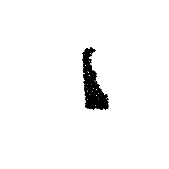

**View Example**

```r
dat7 <- DBgetPlots(states = "Rhode Island",
                   eval = "FIA",
                   eval_opts = eval_options(Cur = TRUE,
                                            Type = c("VOL", "CHNG", "P2VEG"))
                   )
```

**output**

```
## Inventory years by state...
##
##  ## STATUS: GETTING PLOT/COND CHANGE DATA ( RI ) ...
```

```r
names(dat7)
```

**output**

```
##  [1] "states"                 "tabs"                   "tabIDs"
##  [4] "dbqueries"              "puniqueid"              "xy_PUBLIC"
##  [7] "pop_plot_stratum_assgn" "evalid"                 "pltcnt"
## [10] "invyrs"                 "evalInfo"               "args"
```

```r
tabs7 <- dat7$tabs
names(tabs7)
```

**output**

```
## [1] "pltu"      "tree"      "vsubpstr"  "subplot"   "subp_cond" "plt"
## [7] "cond"
```

```r
ppsa7 <- dat7$pop_plot_stratum_assgn
table(ppsa7$EVALID)
```

**output**

```
##
## 442101 442103 442110
##    227    204     15
```

#### Example 8: Get data for multiple evalids

**View Example**

```r
dat8 <- DBgetPlots(eval = "FIA",
                   eval_opts = eval_options(Cur = TRUE,
                                            evalid = c(101800, 101801, 101803))
                   )
```

**output**

```
##
##  ## STATUS: GETTING PLOT/COND CHANGE DATA ( DE ) ...
```

```r
names(dat8)
```

**output**

```
##  [1] "states"                 "tabs"                   "tabIDs"
##  [4] "dbqueries"              "puniqueid"              "xy_PUBLIC"
##  [7] "pop_plot_stratum_assgn" "evalid"                 "pltcnt"
## [10] "invyrs"                 "evalInfo"               "args"
```

```r
tabs8 <- dat8$tabs
names(tabs8)
```

**output**

```
## [1] "pltu"      "tree"      "subplot"   "subp_cond" "grm"       "plt"
## [7] "cond"
```

```r
ppsa8 <- dat8$pop_plot_stratum_assgn
table(ppsa8$EVALID)
```

**output**

```
##
## 101800 101801 101803
##    436    397    374
```

#### Example 9: Get data for multiple states by Endyr

**View Example**

```r
dat9 <- DBgetPlots(states = c("Connecticut", "South Carolina"),
                   eval = "FIA",
                   eval_opts = eval_options(Cur = TRUE,
                                            evalType = "ALL",
                                            Endyr = 2017),
                   )
```

**output**

```
## Inventory years by state...
```

```r
names(dat9)
```

**output**

```
##  [1] "states"                 "tabs"                   "tabIDs"
##  [4] "dbqueries"              "puniqueid"              "xy_PUBLIC"
##  [7] "pop_plot_stratum_assgn" "evalid"                 "pltcnt"
## [10] "invyrs"                 "evalInfo"               "args"
```

```r
tabs9 <- dat9$tabs
names(tabs9)
```

**output**

```
## [1] "plt"  "cond"
```

```r
ppsa9 <- dat9$pop_plot_stratum_assgn
table(ppsa9$EVALID)
```

**output**

```
##
##  91700 451700
##    537   3676
```

#### Example 10: Get data for multiple eval Endyrs

**View Example**

```r
dat10 <- DBgetPlots(states = "Vermont",
                    eval = "FIA",
                    eval_opts = eval_options(Cur = TRUE,
                                             evalType = "VOL",
                                             Endyr = 2015:2019),
                    )
```

**output**

```
## Inventory years by state...
```

```r
names(dat10)
```

**output**

```
##  [1] "states"                 "tabs"                   "tabIDs"
##  [4] "dbqueries"              "puniqueid"              "xy_PUBLIC"
##  [7] "pop_plot_stratum_assgn" "evalid"                 "pltcnt"
## [10] "invyrs"                 "evalInfo"               "args"
```

```r
tabs10 <- dat10$tabs
names(tabs10)
```

**output**

```
## [1] "tree" "plt"  "cond"
```

```r
ppsa10 <- dat10$pop_plot_stratum_assgn
table(ppsa10$EVALID)
```

**output**

```
##
## 501501 501601 501701 501801 501901
##   1101   1122   1125   1125   1124
```

#### Example 11: Get data for multiple inventory years

**View Example**

```r
dat11 <- DBgetPlots(states = "Vermont",
                    eval = "custom",
                    eval_opts = eval_options(invyrs = 2012:2014,
                                             evalType = "ALL")
                    )
```

**output**

```
## Inventory years by state...
```

```r
names(dat11)
```

**output**

```
##  [1] "states"    "tabs"      "tabIDs"    "dbqueries" "puniqueid" "xy_PUBLIC"
##  [7] "pltcnt"    "invyrs"    "evalInfo"  "args"
```

```r
tabs11 <- dat11$tabs
names(tabs11)
```

**output**

```
## [1] "plt"  "cond"
```

```r
plt11 <- tabs11$plt

table(plt11$INVYR)
```

**output**

```
##
## 2012 2013 2014
##  240  239  167
```

#### Example 12: Get data for Periodic inventory

**View Example**

```r
dat12 <- DBgetPlots(states = "Wyoming",
                    invtype = "PERIODIC",
                    eval = "FIA",
                    eval_opts = list(Cur = TRUE,
                                     evalType = "VOL")
                    )
```

**output**

```
## Inventory years by state...
```

```r
names(dat12)
```

**output**

```
##  [1] "states"                 "tabs"                   "tabIDs"
##  [4] "dbqueries"              "puniqueid"              "xy_PUBLIC"
##  [7] "pop_plot_stratum_assgn" "evalid"                 "pltcnt"
## [10] "invyrs"                 "evalInfo"               "args"
```

```r
tabs12 <- dat12$tabs
names(tabs12)
```

**output**

```
## [1] "tree" "plt"  "cond"
```

```r
plt12 <- tabs12$plt

table(plt12$STATECD, plt12$INVYR)
```

**output**

```
##
##      2000
##   56 9956
```

#### Example 13: Intensity

**View Example**

The objective of this section is to understand the differences when using INTENSITY=1.

```r
## With intensified plots
dat13 <- DBgetPlots(states = "Vermont",
                    eval = "FIA",
                    eval_opts = list(Cur = TRUE,
                                     Type = "ALL"),
                    issp = TRUE
                    )
```

**output**

```
## Inventory years by state...
```

```r
tabs13 <- dat13$tabs
plt13 <- tabs13$plt
spxy13 <- dat13$xy_PUBLIC

## With only P2 plots (intensity1 = TRUE)
dat13b <- DBgetPlots(states = "Vermont",
                     eval = "FIA",
                     eval_opts = list(Cur = TRUE,
                                     Type = "ALL"),
                     intensity1 = TRUE,
                     issp = TRUE
                     )
```

**output**

```
## Inventory years by state...
```

```r
tabs13b <- dat13b$tabs
plt13b <- tabs13b$plt

table(plt13$INVYR)
```

**output**

```
##
## 2014 2015 2016 2017 2018 2019 2020
##  167  178  174  170  167  179  166
```

```r
table(plt13b$INVYR)
```

**output**

```
##
## 2014 2015 2016 2017 2018 2019 2020
##  146  151  147  150  140  155  148
```

```r
spxy13b <- dat13b$xy_PUBLIC


# Display spatial output of public coordinates
plot(sf::st_geometry(spxy13), pch = 16, cex = .5)
plot(sf::st_geometry(spxy13b), pch = 16, cex = .5, add = TRUE, col = "grey")
```

**plot**

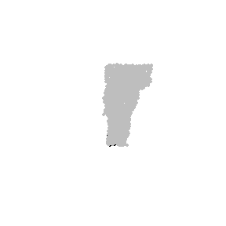

### `DBgetStrata()`

The `DBgetStrata` function queries the FIA database for post-stratification information.

#### Example1: Get strata for the most current evaluation for Wyoming

**View Example**

#### DBgetStrata()

```r
strat1 <- DBgetStrata(states = "Wyoming",
                      eval_opts = eval_options(Cur = TRUE)
                      )
```

**output**

```
## Inventory years by state...
```

```r
names(strat1)
```

**output**

```
##  [1] "unitarea"   "unitvar"    "unitvar2"   "areavar"    "stratalut"
##  [6] "strvar"     "getwt"      "getwtvar"   "evalid"     "pltassgn"
## [11] "pltassgnid"
```

```r
## Look at plot assign data
pltassgn1 <- strat1$pltassgn
head(pltassgn1)
```

**output**

```
##            PLT_CN UNITCD STATECD INVYR ESTN_UNIT COUNTYCD STRATUMCD EVALID
## 1 276307975489998      3      56  2014         5        5         5 561901
## 2 282479222489998      1      56  2013        29       29        12 561901
## 3 339004000489998      3      56  2015       999       11        12 561901
## 4 339004001489998      3      56  2015       999       45        56 561901
## 5 339004002489998      3      56  2016       999       11        12 561901
## 6 339004003489998      3      56  2016       999       11        12 561901
```

```r
unique(pltassgn1$EVALID)
```

**output**

```
## [1] 561901
```

```r
strat1$evalid
```

**output**

```
## $Wyoming
## [1] 561901
```

```r
## Look at area data for estimation unit
strat1$unitarea
```

**output**

```
##    STATECD ESTN_UNIT             ESTN_UNIT_DESCR   ACRES EVALID
## 1       56         1                  County 001 2757613 561901
## 2       56         3                  County 003 2021729 561901
## 3       56         5                  County 005 3072988 561901
## 4       56         7                  County 007 5096959 561901
## 5       56         9                  County 009 2729653 561901
## 6       56        11          County 011 no BHNF 1671974 561901
## 7       56        13                  County 013 5930088 561901
## 8       56        15                  County 015 1428579 561901
## 9       56        17                  County 017 1283969 561901
## 10      56        19                  County 019 2671802 561901
## 11      56        21                  County 021 1720074 561901
## 12      56        23                  County 023 2616954 561901
## 13      56        25                  County 025 3440445 561901
## 14      56        27                  County 027 1681849 561901
## 15      56        29                  County 029 4459826 561901
## 16      56        31                  County 031 1350969 561901
## 17      56        33                  County 033 1617318 561901
## 18      56        35                  County 035 3158807 561901
## 19      56        37                  County 037 6714319 561901
## 20      56        39                  County 039 2701941 561901
## 21      56        41                  County 041 1336034 561901
## 22      56        43                  County 043 1435352 561901
## 23      56        45          County 045 no BHNF 1529616 561901
## 24      56       999 Black Hills National Forest  171572 561901
```

```r
strat1$unitvar
```

**output**

```
## [1] "ESTN_UNIT"
```

```r
strat1$unitvar2
```

**output**

```
## [1] "STATECD"
```

```r
strat1$areavar
```

**output**

```
## [1] "ACRES"
```

```r
## Look at stratification data for estimation unit
strat1$stratalut
```

**output**

```
##    STATECD ESTN_UNIT STRATUMCD                STRATUM_DESCR P2POINTCNT
## 1       56         1         1   High tree cover/Nonprivate         31
## 2       56         1         3    Low tree cover/Nonprivate         22
## 3       56         1        24           Tree cover/Private         12
## 4       56         1        58  Nontree/Nonprivate/Nonvisit         91
## 5       56         1        59     Nontree/Nonprivate/Visit         19
## 6       56         1        68     Nontree/Private/Nonvisit        214
## 7       56         1        69        Nontree/Private/Visit         13
## 8       56         3         6              Nontree/Private         58
## 9       56         3        58  Nontree/Nonprivate/Nonvisit        201
## 10      56         3        59     Nontree/Nonprivate/Visit         16
## 11      56         3      1234                   Tree cover         31
## 12      56         5         5           Nontree/Nonprivate         74
## 13      56         5        68     Nontree/Private/Nonvisit        339
## 14      56         5        69        Nontree/Private/Visit         14
```

[output cut: 177 more lines]

```r
strat1$strvar
```

**output**

```
## [1] "STRATUMCD"
```

```r
strat1$getwtvar
```

**output**

```
## [1] "P1POINTCNT"
```

#### Example 2: Get strata information for a specific evaluation for Wyoming

**View Example**

```r
strat2 <- DBgetStrata(eval_opts = eval_options(evalid = 561200))

unique(strat2$pltassgn$EVALID)
```

**output**

```
## [1] 561200
```

```r
strat2$evalid
```

**output**

```
## $Wyoming
## [1] 561200
```

#### Example 3: Get strata information for Wyoming, evaluation ending in 2014

**View Example**

```r
strat3 <- DBgetStrata(states = "Wyoming",
                      eval_opts = eval_options(Endyr = 2014))
```

**output**

```
## Inventory years by state...
```

```r
unique(strat3$pltassgn$EVALID)
```

**output**

```
## [1] 561401
```

```r
strat3$evalid
```

**output**

```
## $Wyoming
## [1] 561401
```

#### Example 4: Get strata information for a specific set of Wyoming plots

**View Example**

```r
strat4 <- DBgetStrata(dat = WYplt)

head(strat4$unitarea)
```

**output**

```
##   STATECD ESTN_UNIT ESTN_UNIT_DESCR   ACRES EVALID
## 1      56         1      County 001 2757613 561301
## 2      56         3      County 003 2021729 561301
## 3      56         5      County 005 3072988 561301
## 4      56         7      County 007 5096959 561301
## 5      56         9      County 009 2729653 561301
## 6      56        11      County 011 1837124 561301
```

```r
head(WYunitarea)
```

**output**

```
##   STATECD ESTN_UNIT ESTN_UNIT_DESCR   ACRES EVALID
## 1      56         1      County 001 2757613 561301
## 2      56         3      County 003 2021729 561301
## 3      56         5      County 005 3072988 561301
## 4      56         7      County 007 5096959 561301
## 5      56         9      County 009 2729653 561301
## 6      56        11      County 011 1837124 561301
```

**View Example**

```r
strat5 <- DBgetStrata(states = c("Utah", "Wyoming"),
                      eval_opts = eval_options(Cur = TRUE))
```

**output**

```
## Inventory years by state...
```

```r
table(strat5$pltassgn$EVALID)
```

**output**

```
##
## 491901 561901
##   8785   9228
```